# Análise de Internamentos por Cancro Colo-Retal em Portugal: 2017 (*Dados provisórios*)

Autor

Rui Vilas Boas, Valter Loureiro

Data de Publicação

22 de novembro de 2024

[figure not shown]

```r
#Setup

rm(list = ls(all.names = TRUE))
# limpa todos os objetos, incluindo os ocultos
# boa política se houver objetos antigos não relevantes
# melhoria da performance

#install.packages("rio")
#install.packages("janitor")
#install.packages("sf")
#install.packages("gtsummary")
#install.packages("gt")
#install.packages("tidyverse")
library(rio)       # importação de dados
library(janitor)   # limpeza de dados
library(sf)        # ler arquivo GeoJSON
library(gtsummary)
library(gt)
library(tidyverse) # conjunto de pacotes integrados(dplyr. : Para manipulação de dados;
                   #                                stringr: Para manipulação de strings;)
```

# 1 Contexto e Objetivos

De acordo com o Relatório do Registo Oncológico Nacional de 2020, as doenças oncológicas são a segunda principal causa de mortalidade em Portugal, com o Cancro Colorretal (CCR) a ocupar o segundo lugar entre as causas de morte no país.

Esta trabalho serve como produto final do *Curso de Datascience em Healthcare - programação em R* e pretende complementar os relatórios nacionais do CCR com uma perspetiva baseada em dados de internamento. Para esta finalidade, utilizou-se a Base de Dados de Grupos de Diagnóstico Homogéneos (GDH), que contém informações sobre episódios de internamento hospitalar, organizados em categorias de diagnósticos e tratamentos semelhantes.

O presente relatório constitui um exemplo sumário do que poderia ser uma análise mais extensiva, disponibilizado no [GitHub](https://github.com/R-Vilas-Boas/grupo_4_capstone.git) para facilitar a sua continuidade, através de um trabalho colaborativo entre os membros da equipa.

De referir que, a distribuição dos centros de tratamento com capacidade para a gestão autónoma do doente oncológico não é uniforme pelo território nacional exigindo a deslocação de doentes (1). A Base de dados GDH possibilita obter informações sobre o local de residência dos doentes e a unidade de saúde de internamento.

**Metodologia**

A base de dados, como referido é a base de dados modificada de morbilidade hospitalar do Serviço Nacional de Saúde (SNS) ‘’base.GDH’’. Usamos ainda as bases de dados: codigos_diagnostico_icd10, codigos_residencia, concelhos_portugal_light.

```r
base_gdh <- import("datasets/base_gdh/base_gdh_icd10_no_freg.csv")|>
  clean_names()
n_internamentos <- nrow(base_gdh)
#names(base_gdh)  # Usado para saber os nomes das variáveis a possiveis de estudar
```

**Definição de caso**

Os episódios de CCR foram considerados aqueles com os códigos ICD-10 neoplasia maligna colorretal.

**Cod_diagnostico**: variável categórica que identifica o diagnóstico principal durante o internamento, codificado de acordo com a ICD-10-CM/PCS (“*International Classification of Diseases, 10th Revision, Clinical Modification/Procedures*”). Foram selecionados os códigos C18 a C21.

```r
colon <- "C18"
rectossigmoid <-"C19"
recto <- "C20"
anal <- "C21"

colo_rectal <- paste(colon, rectossigmoid, recto, anal, sep = "|")

base_gdh_ICD10_C18_C21 <- base_gdh |>
  filter(str_detect(cod_diagnostico, colo_rectal))
n_inter_colo_rectal <- nrow(base_gdh_ICD10_C18_C21)
tax_inter_colo_rectal <- round(n_inter_colo_rectal/n_internamentos*1000, 2)
```

```r
codigos_icd10 <- import("datasets/base_gdh/codigos_diagnostico_icd10.csv")|>
  clean_names()
#names(codigos_icd10)  # Usado para saber os nomes das variáveis a possiveis de estudar

cod_colo_rectal <- c(colon, rectossigmoid, recto, anal)
df_icd10_to_pt <- codigos_icd10 |>
  filter(codigo_icd_10_cm %in% cod_colo_rectal) |>
  select(codigo = codigo_icd_10_cm, descricao = pt)
df_icd10_to_pt|>
  knitr::kable(col.names = c("Código", "Descrição"))
```

| Código | Descrição |
| --- | --- |
| C18 | Neoplasia maligna do cólon |
| C19 | Neoplasia maligna da junção rectossigmoideia |
| C20 | Neoplasia maligna do recto |
| C21 | Neoplasia maligna do ânus e do canal anal |

```r
clean_ICD10_C18_C21 <- base_gdh_ICD10_C18_C21 |>
  select(-seq_number, -hosp_id, -hora_entrada, -hora_urgencia, -freguesia) |>
  rowwise() |>
  mutate(diagnostico = {
    matching_desc <- df_icd10_to_pt |>
      filter(str_detect(cod_diagnostico, codigo)) |>
      pull(descricao)
    if (length(matching_desc) > 0) matching_desc else NA_character_
  })
```

**Descrição das variáveis empregadas**

Além das variáveis de interesse referentes ao CCR foram selecionadas as seguintes variáveis:

**Sexo**: variável categórica com 3 valores possíveis (masculino, feminino, indeterminado), que indica o sexo do utente.

**Idade**: variável numérica que representa a idade do utente (em anos).

**Distrito**: variável numérica com 30 valores possíveis, cujos códigos apresentam dois dígitos e correspondem à codificação dos distritos existentes à data de extração dos dados, referente ao distrito de residência do utente.

**Concelho**: variável numérica com 313 valores possíveis, cujos códigos apresentam dois dígitos e correspondem à codificação de concelhos existentes no SONHO à data de extração dos dados referente ao concelho de residência do utentes.

**Dias_int**: variável ordinal que indica o total de dias de internamento do utente na instituição de saúde, em conformidade com a definição estatística de tempo de internamento estabelecida pela portaria em vigor à data de extração dos dados.

# 2 Análise Exploratória dos Dados

Do total de internamentos (1711879), 9898 são internamentos de doentes com neoplasia colo-rectal (5.78‰).

```r
summary_df <- clean_ICD10_C18_C21 |>
  group_by(diagnostico) |>
  summarise(
    count = n(),
    percentage = round((n() / nrow(clean_ICD10_C18_C21)) * 100, 2),
    mean_age = round(mean(idade, na.rm = TRUE), 2),
    mean_int_days = round(mean(dias_int, na.rm = TRUE), 2)
  ) |>
  arrange(desc(count))

summary_df|>
  knitr::kable(col.names = c("Diagnóstico", "Nº Casos", "Percentagem", "Média Idades", "Média Dias Internamento"))
```

| Diagnóstico | Nº Casos | Percentagem | Média Idades | Média Dias Internamento |
| --- | --- | --- | --- | --- |
| Neoplasia maligna do cólon | 6469 | 65.36 | 70.40 | 11.93 |
| Neoplasia maligna do recto | 2629 | 26.56 | 68.53 | 13.17 |
| Neoplasia maligna da junção rectossigmoideia | 586 | 5.92 | 68.78 | 11.98 |
| Neoplasia maligna do ânus e do canal anal | 214 | 2.16 | 66.35 | 15.27 |

# 3 Visualização de Dados

Aqui apresentamos a distribuição de idades entre homens e mulheres.

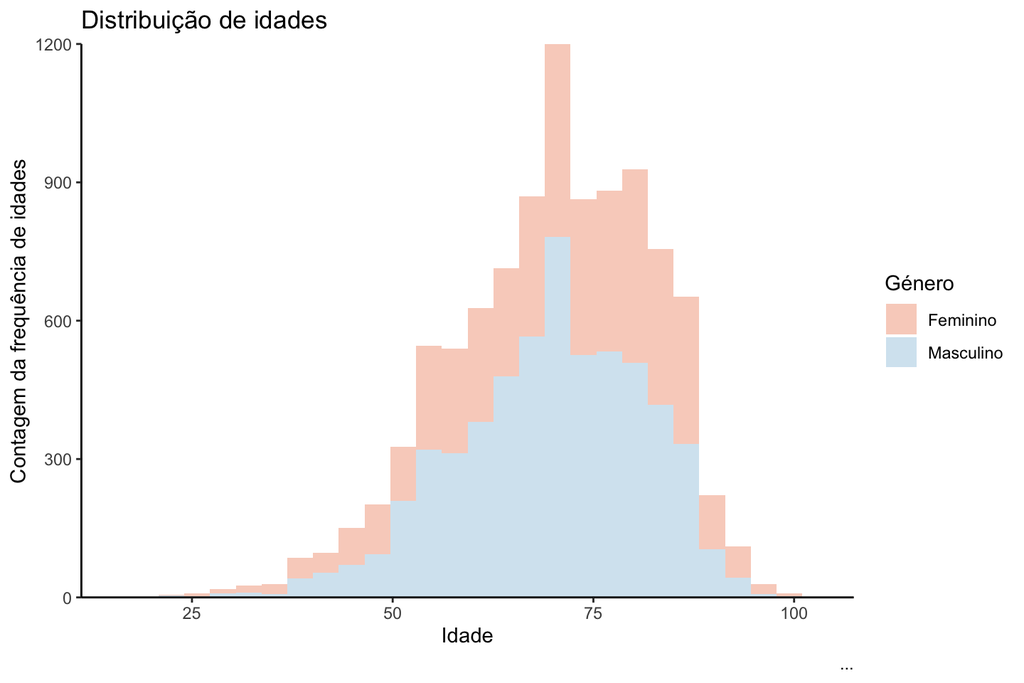

```r
p1 <- ggplot(data = clean_ICD10_C18_C21,
       aes(x = idade, fill = sexo)) +
  geom_histogram(alpha = .4) +
  labs(
    title = "Distribuição de idades",
    y = "Contagem da frequência de idades",
    fill = "Género",
    x = "Idade",
    caption = "..."
  ) +
  coord_cartesian(expand = FALSE) +
  theme_classic() +
  scale_fill_manual(values = c("#ef8a62","#91bfdb"))


p2 <- ggplot(data = clean_ICD10_C18_C21, aes(x = as.factor(sexo), y = idade, fill = as.factor(sexo))) +
  geom_boxplot(alpha = .4) +
  labs(x = "Género", y = "Idade", fill= "Género") +
  theme_classic() +
  scale_fill_manual(values = c("#ef8a62","#91bfdb"))

p1
```

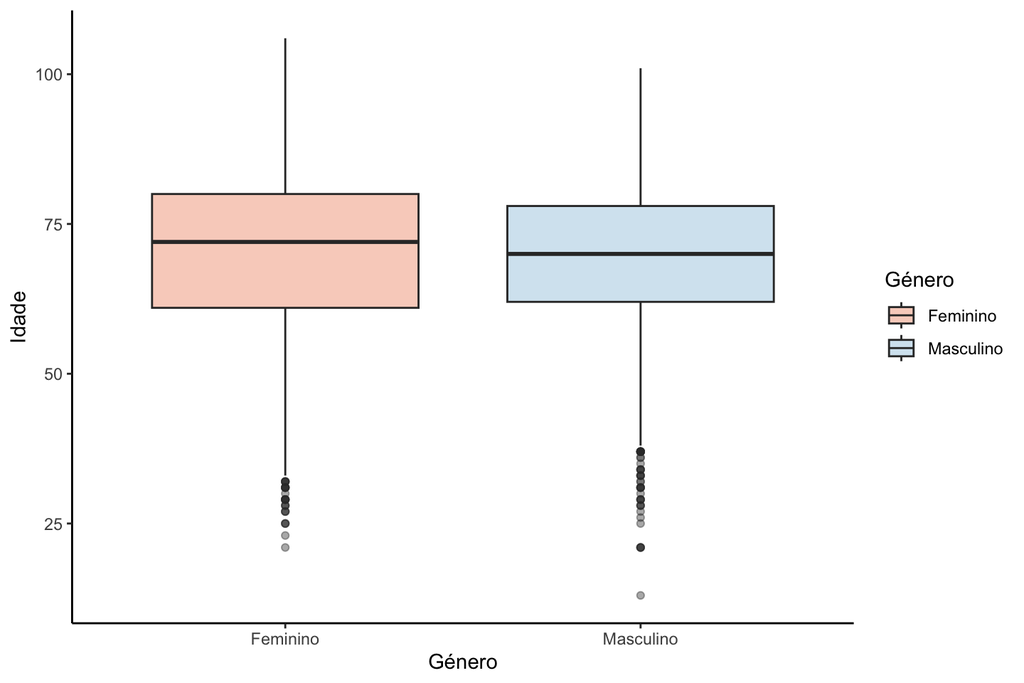

```r
p2
```

A relação entre dias de internamento e idade:

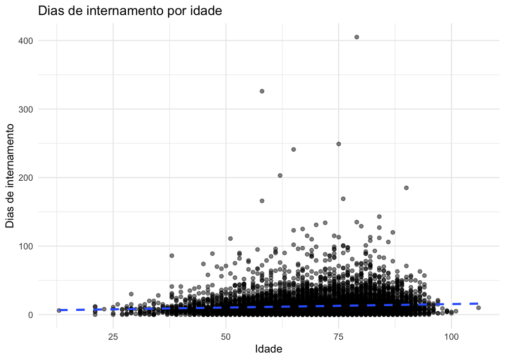

```r
p2 <- ggplot(data = clean_ICD10_C18_C21,
             aes(x = idade,
                 y = dias_int)) +
  geom_point(alpha = 0.5) +
  geom_smooth(method = lm,
              se = FALSE,
              linetype = "dashed") +
  labs(title = "Dias de internamento por idade",
       y = "Dias de internamento",
       x = "Idade") +
  theme_minimal()

p2
```

```r
codigos_residencia <- import("datasets/base_gdh/codigos_residencia.csv")|>
  clean_names()


clean_ICD10_C18_C21_map <- clean_ICD10_C18_C21 |>
  left_join(codigos_residencia,
            by = c("distrito" = "cod_dist", "concelho" = "cod_conc"))|>
  select(-distrito, -concelho, -cod_freg)


populacao <- import("datasets/AER2022_II_01/II_01_02.csv")|>
  clean_names()|>
  select(v1,v2)
```

```r
#mapa
comm_pt <- st_read(
  "datasets/map_json_portugal/concelhos_portugal_light.json",
  quiet = TRUE) |>
  clean_names()
```

# 4 Modelos Estatísticos

```r
tabela1 <- tbl_summary(
  clean_ICD10_C18_C21_map,
  include = c(sexo, idade, dias_int , mortalidade_apr31),
  by = diagnostico,
  missing = "no",
  statistic = list(
  all_continuous() ~ "{mean} ({sd})",
  all_categorical() ~ "{n} / {N} ({p}%)"),
  label =list(
    sexo= "Sexo",
    idade= "Idade",
    dias_int= "Dias de internamento",
    mortalidade_apr31="Mortalidade"
  )
) |>
  modify_spanning_header() |>
  add_n() |>
  add_p() |>
  modify_header(label = "**Característica**") |>
  bold_labels()|> #
  as_gt() |>
  tab_header(
    title = md("**Análise do Cancro Colo-rectal em Portugal**") ,
  ) |>

  fmt_number( decimals = 2) |>
  opt_stylize(style = 1, color = "gray") |>
  opt_align_table_header(align = "left")


tabela1
```

**Análise do Cancro Colo-rectal em Portugal**

| **Característica** | **N** | **Neoplasia maligna da junção rectossigmoideia** N = 586<sup>1</sup> | **Neoplasia maligna do ânus e do canal anal** N = 214<sup>1</sup> | **Neoplasia maligna do cólon** N = 6,469<sup>1</sup> | **Neoplasia maligna do recto** N = 2,629<sup>1</sup> | **p-value**<sup>2</sup> |
| --- | --- | --- | --- | --- | --- | --- |
| Sexo | 9,898 |  |  |  |  | 0.00 |
| Feminino |  | 236 / 586 (40%) | 98 / 214 (46%) | 2,756 / 6469 (43%) | 993 / 2629 (38%) |  |
| Masculino |  | 350 / 586 (60%) | 116 / 214 (54%) | 3,713 / 6469 (57%) | 1,636 / 2629 (62%) |  |
| Idade | 9,898 | 69 (13) | 66 (13) | 70 (12) | 69 (13) | 0.00 |
| Dias de internamento | 9,898 | 12 (13) | 15 (20) | 12 (14) | 13 (16) | 0.00 |
| Mortalidade | 9,898 |  |  |  |  | 0.00 |
| Extremo |  | 24 / 586 (4.1%) | 4 / 214 (1.9%) | 263 / 6469 (4.1%) | 57 / 2629 (2.2%) |  |
| Major |  | 93 / 586 (16%) | 37 / 214 (17%) | 1,035 / 6469 (16%) | 342 / 2629 (13%) |  |
| Menor |  | 196 / 586 (33%) | 80 / 214 (37%) | 2,374 / 6469 (37%) | 1,126 / 2629 (43%) |  |
| Moderado |  | 273 / 586 (47%) | 93 / 214 (43%) | 2,797 / 6469 (43%) | 1,104 / 2629 (42%) |  |

<sup>1</sup> n / N (%); Mean (SD)  
<sup>2</sup> Pearson’s Chi-squared test; Kruskal-Wallis rank sum test

# 5 Referências

1.

Acesso a Cuidados de Saúde nos Estabelecimentos do SNS e Entidades Convencionadas em 2019. Ministério da Saúde; 2019.